# StatComp Project 2: Scottish weather

Lewis MacRae (s1506414, lew98)

# 1 Weather data

We will investigate daily temperature data collected from eight weather stations in Scotland, the locations of which are displayed in the map below (produced using Google Maps). The data set covers the time period from 1 January 1960 to 31 December 2018.

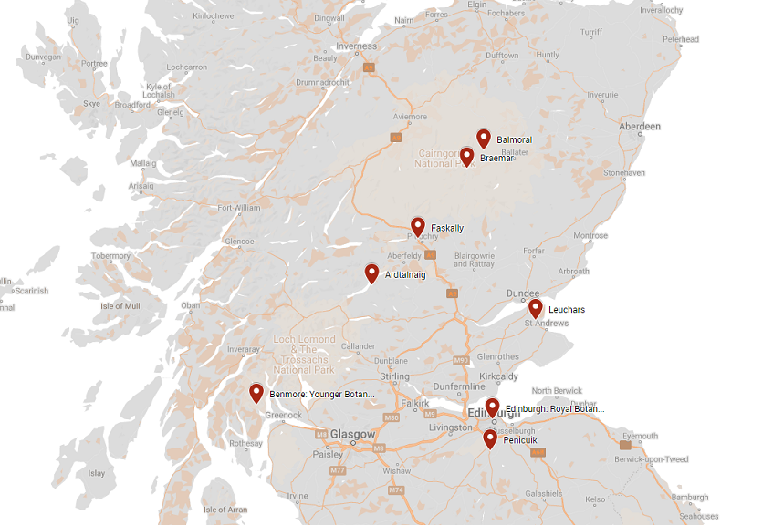

```r
# Load function definitions
source("my_functions.R")

# Load common packages
suppressPackageStartupMessages(library(tidyverse))
suppressPackageStartupMessages(library(StatCompLab))
theme_set(theme_bw())

# Load weather data
data(ghcnd_stations, package = "StatCompLab")
data(ghcnd_values, package = "StatCompLab")

# Set seed for consistency
set.seed(666)
```

# 2 Climate trends

## 2.1 Monthly trends

First, we will estimate the long term temporal trend in the monthly TMIN averages across the years 1960 - 2018, for each weather station. The plots below show the estimated trend and an associated 95% confidence interval for each station and month. The trends and confidence interval endpoints have been scaled up by a factor of 100 to obtain an estimated change per century, instead of change per year. This is to give us temperature numbers in the single digits, which are more relatable for humans.

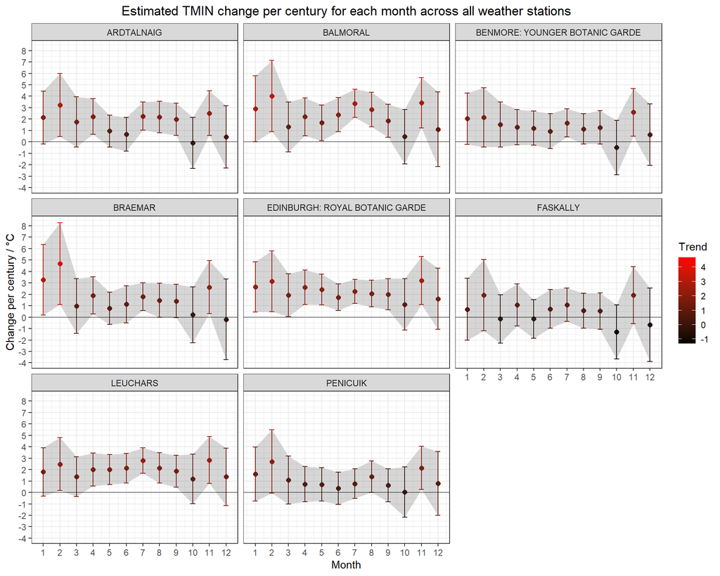

```r
# Join station and value data into one data frame
ghcnd <- left_join(ghcnd_stations, ghcnd_values, by = "ID")

# Get monthly average TMIN for each station, month, and year
tmin_monthly_avg <- ghcnd %>%
  filter(Element == "TMIN") %>%
  group_by(Name, Year, Month) %>%
  summarise(Monthly_Average = mean(Value), .groups = "drop")

# Get station names and initialise data.frame to store estimated trend information
stns <- unique(ghcnd$Name)
monthly_trends <- data.frame(
  Name = rep(stns, each = 12),
  Month = rep(1:12, 8),
  Trend = NA,
  CI_Lower = NA,
  CI_Upper = NA
)

# Estimate monthly trends for each station using lm
for (stn in 1:8) {
  for (month in 1:12) {
    mod <- lm(Monthly_Average ~ Year,
      data = tmin_monthly_avg %>% filter(Name == stns[stn] & Month == month)
    )
    # Extract the February, Braemar linear model for discussion purposes later
    if (stn == 1 & month == 2) {
      braemar_feb_mod <- mod
    }
    CI <- confint(mod, "Year", level = 0.95)
    # Scale trend and CI endpoints by factor of 100 for change per century
    monthly_trends[(stn - 1) * 12 + month, 3] <- 100 * coef(mod)["Year"]
    monthly_trends[(stn - 1) * 12 + month, 4] <- 100 * CI[1]
    monthly_trends[(stn - 1) * 12 + month, 5] <- 100 * CI[2]
  }
}

# Plot the magnitude of the estimated monthly trend and associated 95%
# confidence interval for each station.
monthly_trends %>%
  ggplot(aes(Month, Trend)) +
  geom_point(aes(colour = Trend), size = 2) +
  geom_errorbar(aes(ymin = CI_Lower, ymax = CI_Upper, colour = Trend), width = 0.3) +
  geom_ribbon(aes(ymin = CI_Lower, ymax = CI_Upper), alpha = 0.2) +
  geom_hline(aes(yintercept = 0), alpha = 0.5) +
  scale_x_continuous(breaks = 1:12) +
  scale_y_continuous(breaks = -4:8) +
  scale_colour_gradient(low = "black", high = "red") +
  facet_wrap(~Name) +
  labs(
    y = "Change per century / °C",
    title = "Estimated TMIN change per century for each month across all weather stations"
  ) +
  theme(plot.title = element_text(hjust = 0.5))
```

Almost all of the estimated trends are positive - the models are suggesting that the monthly average TMIN is increasing in the long term for most months across all weather stations. The trends follow very roughly the same seasonal pattern for each station, with the highest trend in February or November and the lowest in October for most stations. The confidence intervals are wider in the colder months, indicating greater uncertainty in the trend estimations for those months, and narrower in the warmer months.

Based on these linear models, we might be tempted to predict the average monthly TMIN values in a century’s time at a given weather station. However, the usual concerns apply for linear regression. For example, let us look at the model for February at the Braemar weather station, which had the largest estimated trend.

```r
# Display the linear model for February, Braemar in table and plot form.
knitr::kable(data.frame(Intercept = coef(braemar_feb_mod)[[1]], Slope = 100 * coef(braemar_feb_mod)[[2]]),
  align = "cc",
  col.names = c("Estimated intercept / °C", "Estimated change per century / °C"),
  digits = 2,
  caption = "Linear model coefficients, February, Braemar weather station"
)
```

Linear model coefficients, February, Braemar weather station

| Estimated intercept / °C | Estimated change per century / °C |
| --- | --- |
| -95.15 | 4.68 |

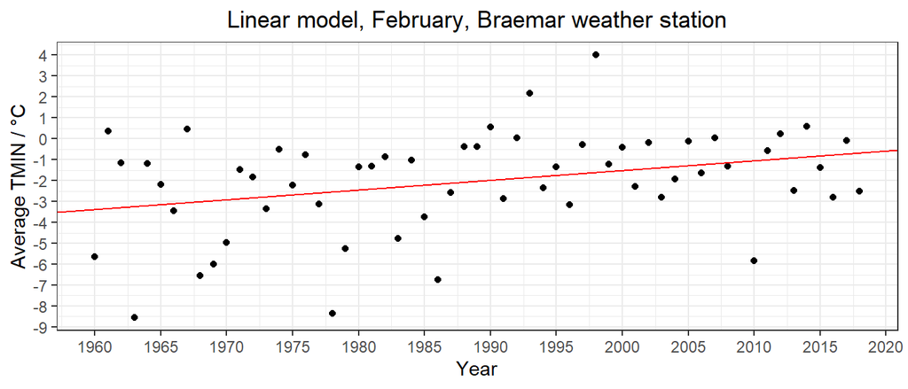

```r
tmin_monthly_avg %>%
  filter(Name == "BRAEMAR" & Month == 2) %>%
  ggplot(aes(x = Year, y = Monthly_Average)) +
  geom_point() +
  geom_abline(aes(intercept = coef(braemar_feb_mod)[[1]], slope = coef(braemar_feb_mod)[[2]]), colour = "red") +
  scale_x_continuous(breaks = seq(from = 1960, to = 2020, by = 5)) +
  scale_y_continuous(breaks = -9:4) +
  labs(
    y = "Average TMIN / °C",
    title = "Linear model, February, Braemar weather station"
  ) +
  theme(plot.title = element_text(hjust = 0.5))
```

The data set only spans the years 1960 - 2018, a range of 58 years, so we should be careful not to extrapolate too far in either direction. As stated before, the fitted trends were scaled up by a factor of 100 for readability purposes only - we certainly could not have confidence in February average TMIN predictions at Braemar in the years 1860 or 2118, for example. Indeed, we see the model intercept is -95 degrees Celsius - in practical terms, the model predicts an average of -95°C for February in the year 0, which is clearly nonsense (people were living in Scotland in the year 0). Rather, we could say that based on this linear model we expect the February average TMIN value at the Braemar weather station to increase or decrease, depending on which direction we look, at a rate of roughly 4.7 degrees per century in the short to medium term (on the scale of years or decades). A similar discussion holds for the other linear models.

## 2.2 Seasonally varying variability

We focus our attention now on the weather station at Ardtalnaig, and consider whether the temperature variability is the same for each month of the year. In particular, we calculate the monthly TMIN averages as in 2.1, and then find the daily TMIN residuals from this monthly average. In the plot below, the points show the variance of these residuals for each month and the horizontal line shows the variance of the entire set of residuals.

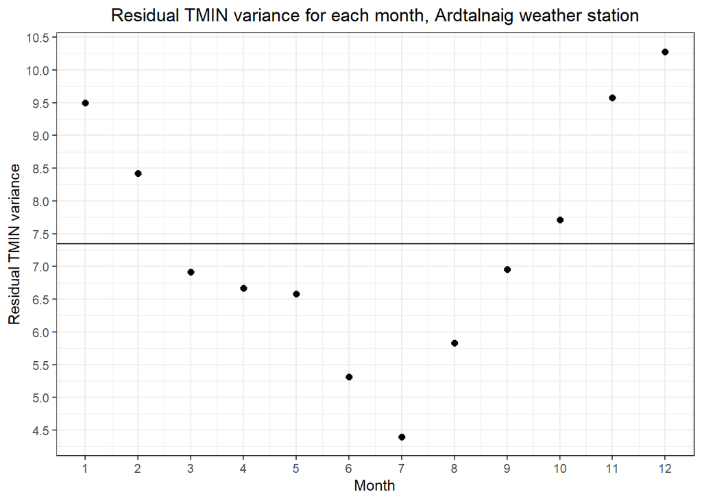

```r
# Extract station data for Ardtalnaig, filter for TMIN only, and attach monthly
# averages to each row
ard_tmin_monthly_avg <- left_join(
  filter(ghcnd, Name == "ARDTALNAIG" & Element == "TMIN"),
  filter(tmin_monthly_avg, Name == "ARDTALNAIG"),
  by = c("Name", "Year", "Month")
)

# Calculate and append daily TMIN residuals from monthly averages
ard_tmin_monthly_avg <- ard_tmin_monthly_avg %>%
  mutate(Residual = Value - Monthly_Average)

# Plot the residual TMIN variance for each month and the overall TMIN variance.
ard_tmin_monthly_avg %>%
  group_by(Month) %>%
  summarise(variance = var(Residual)) %>%
  ggplot(aes(x = Month, y = variance)) +
  geom_point(size = 2) +
  geom_hline(aes(yintercept = var(ard_tmin_monthly_avg$Residual))) +
  scale_x_continuous(breaks = 1:12) +
  scale_y_continuous(breaks = seq(from = 4.5, to = 10.5, by = 0.5)) +
  labs(
    y = "Residual TMIN variance",
    title = "Residual TMIN variance for each month, Ardtalnaig weather station"
  ) +
  theme(plot.title = element_text(hjust = 0.5))
```

The plot shows that for this data set the residual variance is higher than average for the months October - February, and lower for March - September. We want to check if these results are statistically significant. To investigate this, we will perform a randomisation test for each month, with hypotheses

$$\begin{align*}
H_0 &: \text{The residual variance is the same for all months of the year}\\
H_1 &: \text{The residual variance for month } m \text{ is higher than the overall variance}
\end{align*}$$

for $m = 1,\ldots,12$. Let $\{R_1,\ldots,R_N\}$ be the entire set of residuals, and $\{R_1^{(m)},\ldots,R_{N_m}^{(m)}\}$ be the set of residuals for the month $m$.

Consider a given month $m$. To calculate a $p$-value for this month, we will first compute the test statistic

$$T_m = \text{Var}(\{R_1^{(m)},\ldots,R_{N_m}^{(m)}\}) - \text{Var}(\{R_1,\ldots,R_N\}).$$
Large positive values of this test statistic indicate deviations from $H_0$ in favour of $H_1$. Then, for $j=1,\ldots,J$, we will permute the residuals to obtain a reordered set $\{S_1^{(j)},\ldots,S_N^{(j)}\}$, and then calculate a test statistic $T_m^{(j)}$ in the same way as $T_m$, except using the reordered residuals.

We then take the average

$$\frac{1}{J} \sum_{j=1}^J \mathbb{I}\{ T_m^{(j)} \geq T_m \}$$

as the $p$-value for month $m$. The $p$-values calculated in this way are shown in the table below, where we have used $J = 5000$ permutations.

```r
# The p-values were calculated in my_code.R, displayed in 4.2.
p_values <- readRDS(file = "data/residual_variance_pvalues.rds")

# Vector of strings like "01 (January)" for display purposes in tables and plots.
month_list <- paste(formatC(1:12, width = 2, format = "d", flag = "0"), " (", month.name[1:12], ")", sep = "")

knitr::kable(
  data.frame(
    Month = month_list,
    p_value = p_values
  ),
  col.names = c("Month", "p-value"),
  align = "cc",
  digits = 4,
  caption = "Estimated p-values"
)
```

Estimated p-values

| Month | p-value |
| --- | --- |
| 01 (January) | 0.0000 |
| 02 (February) | 0.0000 |
| 03 (March) | 0.9574 |
| 04 (April) | 0.9974 |
| 05 (May) | 0.9992 |
| 06 (June) | 1.0000 |
| 07 (July) | 1.0000 |
| 08 (August) | 1.0000 |
| 09 (September) | 0.9442 |
| 10 (October) | 0.0790 |
| 11 (November) | 0.0000 |
| 12 (December) | 0.0000 |

Based on this, for the months November - February we would reject $H_0$ in favour of $H_1$ at all significance levels. For the months March - September we would not reject $H_0$ in favour of $H_1$. For October, we obtain a $p$-value of roughly 0.08, so we would reject $H_0$ in favour of $H_1$ at the 0.1 significance level but not at the 0.05 significance level.

The results of this test support, at least for the Ardtalnaig weather station, our observation from the plot in 2.1 that the confidence intervals were wider in the colder months, indicating greater uncertainty in the TMIN trend estimations, possibly as a result of higher TMIN variability in these months.

It is notable that this test does not explicitly check for monthly residual variances being lower than the overall residual variance, which might help to explain the narrower confidence intervals in the warmer months. This would require a similar but different randomisation test than the one carried out here.

# 3 Spatial weather prediction

## 3.1 Estimation

In this section, we will switch our focus to the Braemar weather station. For each month we will fit a linear model for the daily TMAX value at Braemar, using the daily TMAX values at the other weather stations as covariates. The scatter plots below show the results of this linear modelling, with the fitted daily TMAX values plotted against the observed daily TMAX values, for each month. The red line is the graph of $y = x$. Points on this line would be “perfect predictions”.

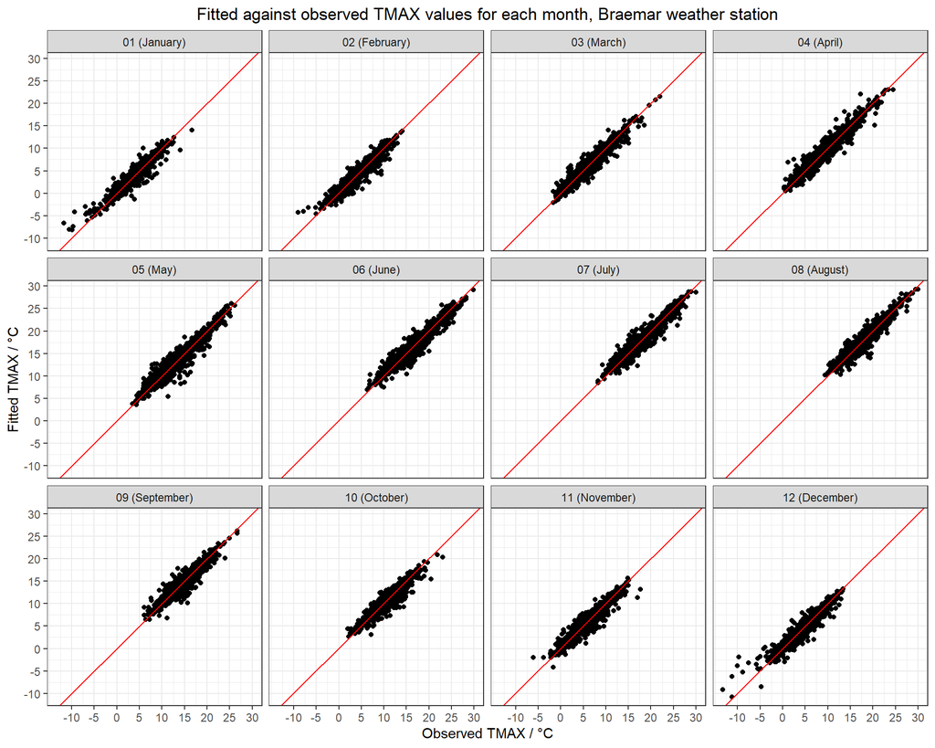

```r
# Restructure data for linear modelling. First pivot_wider gives us the TMAX
# values in their own column, second pivot_wider gives us the TMAX values for
# each weather station in their own columns. Finally, remove any rows with an
# NA value for daily TMAX at any station.
station_tmax <- ghcnd %>%
  select(-ID, -Latitude, -Longitude, -Elevation, -DecYear) %>%
  pivot_wider(names_from = Element, values_from = Value) %>%
  select(-TMIN, -PRCP) %>%
  pivot_wider(names_from = Name, values_from = TMAX) %>%
  filter(across(everything(), ~ !is.na(.x)))

# Rename columns to make formulas easier and avoid problems with blank spaces.
# Station names
# S1 = BRAEMAR
# S2 = BALMORAL
# S3 = ARDTALNAIG
# S4 = FASKALLY
# S5 = LEUCHARS
# S6 = PENICUIK
# S7 = EDINBURGH: ROYAL BOTANIC GARDE
# S8 = BENMORE: YOUNGER BOTANIC GARDE
colnames(station_tmax) <- c("Year", "Month", "Day", paste("S", 1:8, sep = ""))

# We will extract the coefficients from the models for further discussion later
coefficient_df <- data.frame(Month = rep(month_list, each = 7), Station = rep(2:8, 12), Coef = NA)

# Fit the model for each month using the station_lm function which is shown in
# 4.1. Append the predictions for each month to one vector for plotting purposes.
tmax_fit <- vector()
for (m in 1:12) {
  month_model <- station_lm(filter(station_tmax, Month == m))
  coefficient_df[((m - 1) * 7 + 1):(m * 7), 3] <- coef(month_model)[2:8]
  tmax_fit <- c(tmax_fit, predict(month_model))
}

# Fix the ordering in the TMAX data to match up with the tmax_fit vector
# calculated above, then append this vector so the data.frame is ready for plotting.
station_tmax_fit <- station_tmax %>%
  arrange(Month) %>%
  select(Year:S1) %>%
  mutate(Month = paste(formatC(Month, width = 2, format = "d", flag = "0"), " (", month.name[Month], ")", sep = ""), TMAX_Fitted = tmax_fit)

# Plot the TMAX predictions against observations, with a subplot for each month.
ggplot(station_tmax_fit, aes(x = S1, y = TMAX_Fitted)) +
  geom_point() +
  geom_abline(aes(intercept = 0, slope = 1), colour = "Red") +
  facet_wrap(~Month) +
  scale_x_continuous(breaks = seq(from = -10, to = 30, by = 5)) +
  scale_y_continuous(breaks = seq(from = -10, to = 30, by = 5)) +
  labs(
    x = "Observed TMAX / °C",
    y = "Fitted TMAX / °C",
    title = "Fitted against observed TMAX values for each month, Braemar weather station"
  ) +
  theme(plot.title = element_text(hjust = 0.5))
```

Based on this plot, the fit is reasonable. For each month, the scatter points are spread evenly to either side of the red line, suggesting little or no bias in the models. The points are fairly tight about the red line, indicating small residuals, although this is less clear than the low bias. The quality of fit seems mostly uniform across the months.

One deviation from this is at the very lowest end of the TMAX range, in the months of December - February. Here we see a slight skew upwards, where the model is predicting higher than observed TMAX values. This could indicate that the model is biased for very low TMAX values, which only occur in the winter months, but with only these few data points we cannot be certain about this.

Now let us look at the estimated coefficients for the weather station covariates of these linear models. In the plot below, the stations have been numbered as follows.

- 2 - Balmoral
- 3 - Ardtalnaig
- 4 - Faskally
- 5 - Leuchars
- 6 - Penicuik
- 7 - Edinburgh: Royal Botanic Garden
- 8 - Benmore: Younger Botanic Garden

It should be noted that this numbering is not in any order, such as increasing distance from Braemar, but is just the order initially given in the data set.

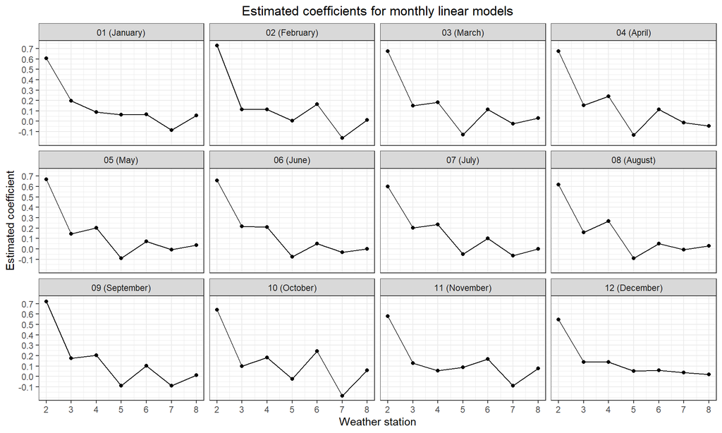

```r
# Display the coefficient information in plot form
ggplot(coefficient_df, aes(x = Station, y = Coef)) +
  geom_point() +
  geom_line() +
  facet_wrap(~Month) +
  scale_x_continuous(breaks = 2:8) +
  scale_y_continuous(breaks = seq(from = -0.1, to = 0.8, by = 0.1)) +
  labs(
    x = "Weather station",
    y = "Estimated coefficient",
    title = "Estimated coefficients for monthly linear models"
  ) +
  theme(plot.title = element_text(hjust = 0.5))
```

## 3.2 Assessment

Now we will assess the models. For each month, we estimate the expected Absolute Error and Dawid-Sebastiani scores for the TMAX predictions at the Braemar weather station using 10-fold cross validation. To achieve this, we split the TMAX data into ten randomised subsets and then loop over each subset, fitting the model with the other nine subsets and using the left-out subset as the new prediction data for scoring. We take the average of the mean scores obtained at each iteration of this loop to be our estimate of the expected scores. The results are displayed in the table and plot below.

```r
scores <- data.frame(Month = month_list, AE_CV = NA, DS_CV = NA)

# The randomisation test as described above.
for (m in 1:12) {
  # Filter to month m and append a Group column containing a uniformly random
  # number between 1 and 10 inclusive.
  station_tmax_subsets <- station_tmax %>%
    filter(Month == m) %>%
    mutate(Group = sample(1:10, nrow(filter(station_tmax, Month == m)), replace = TRUE))

  scores_AE <- numeric(10)
  scores_DS <- numeric(10)

  for (grp in 1:10) {
    # Fit the model using only the data from the other nine subsets.
    fit_model <- station_lm(filter(station_tmax_subsets, Group != grp))
    # Obtain predictions based on the grp subset of data. Extract standard error
    # information for use in calculating the DS score.
    pred <- predict(fit_model, newdata = filter(station_tmax_subsets, Group == grp), se.fit = TRUE)
    scores_AE[grp] <- mean(proper_score(
      "ae",
      filter(station_tmax_subsets, Group == grp)$S1,
      median = pred$fit
    ))
    scores_DS[grp] <- mean(proper_score(
      "ds",
      filter(station_tmax_subsets, Group == grp)$S1,
      mean = pred$fit,
      sd = sqrt(pred$se.fit^2 + pred$residual.scale^2)
    ))
  }

  scores[m, 2] <- mean(scores_AE)
  scores[m, 3] <- mean(scores_DS)
}

# Display the estimated expected scores in table and plot form.
knitr::kable(
  scores,
  col.names = c("Month", "Absolute Error CV", "Dawid-Sebastiani CV"),
  align = "ccc",
  digits = 4,
  caption = "Estimated expected Absolute Error and Dawid-Sebastiani scores for Braemar TMAX predictions"
)
```

Estimated expected Absolute Error and Dawid-Sebastiani scores for Braemar TMAX predictions

| Month | Absolute Error CV | Dawid-Sebastiani CV |
| --- | --- | --- |
| 01 (January) | 0.6325 | 0.8514 |
| 02 (February) | 0.6370 | 0.8087 |
| 03 (March) | 0.6459 | 0.7773 |
| 04 (April) | 0.6860 | 0.9395 |
| 05 (May) | 0.7522 | 1.1457 |
| 06 (June) | 0.7390 | 1.0119 |
| 07 (July) | 0.7349 | 0.9943 |
| 08 (August) | 0.6638 | 0.8031 |
| 09 (September) | 0.7031 | 0.9556 |
| 10 (October) | 0.6394 | 0.7983 |
| 11 (November) | 0.6221 | 0.7867 |
| 12 (December) | 0.6384 | 0.9156 |

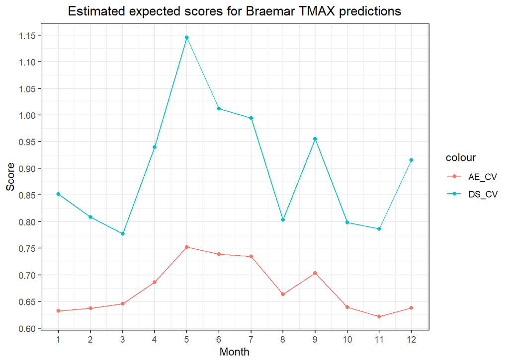

```r
scores %>%
  mutate(Month = 1:12) %>%
  ggplot() +
  geom_line(aes(x = Month, y = AE_CV, col = "AE_CV")) +
  geom_point(aes(x = Month, y = AE_CV, col = "AE_CV")) +
  geom_line(aes(x = Month, y = DS_CV, col = "DS_CV")) +
  geom_point(aes(x = Month, y = DS_CV, col = "DS_CV")) +
  scale_x_continuous(breaks = 1:12) +
  scale_y_continuous(breaks = seq(from = 0.6, to = 1.15, by = 0.05)) +
  labs(
    y = "Score",
    title = "Estimated expected scores for Braemar TMAX predictions"
  ) +
  theme(plot.title = element_text(hjust = 0.5))
```

Across each month, the estimated expected scores for each type do not differ a great deal, particularly for the Absolute Error score (difference of about 0.13 between highest and lowest for AE score, and about 0.37 for Dawid-Sebastiani). The two types of score very roughly follow the same seasonal pattern, with higher scores in the warmer months and lower scores in the colder months (this is clearer for the AE score, compared to the DS score). The highest scores for both types are in the months of May - July.

These estimated expected scores support our conclusions from 3.1. The Absolute Error score takes account of any bias in our predictions. We noted in 3.1 that the points on the scatter plot were spread evenly to either side of the red line, suggesting low bias, and the low AE scores throughout the year agree with this. The Dawid-Sebastiani scores measure both the bias and the variance of the predictions. Compared to the AE scores, the DS scores are higher and fluctuate more throughout the year. This could point to the models being relatively better at lower bias than lower variability.

Overall, the scores suggest that the predictions are good throughout the year; they are perhaps better in the colder months compared to the warmer months, although not by a great deal. To conclude, we could consider the daily TMAX observed at the other seven weather stations as a good predictor of the daily TMAX value at the Braemar weather station, in any given month. This was perhaps to be expected, given that in geographical terms Scotland is quite small - the climate does not vary a large amount across the country. On top of this, the map at the beginning of this report shows that the weather stations do not even cover the entire country.

# 4 Code appendix

## 4.1 Function definitions

```r
# Lewis MacRae (s1506414, lew98)

#' Calculates p-value estimates for randomisation tests defined in 2.2.
#'
#' @param res_data Any data.frame containing a Month and Residual column.
#' @param iter Number of permutations to use in the randomisation test.
#'
#' @return A vector of estimated p-values, one for each month of the year.

res_var_pvalues <- function(res_data, iter) {
  # Overall residual variance is constant throughout this process since
  # we are sampling without replacement.
  overall_var <- var(res_data$Residual)

  # Calculate the initial test stats for each month
  initial_test_stats <- res_data %>%
    group_by(Month) %>%
    summarise(i_test_stat = var(Residual) - overall_var) %>%
    pull(i_test_stat)

  test_stats <- matrix(nrow = iter, ncol = 12)

  # Calculate the test stats for each permutation as described in 2.2 of report.Rmd
  for (loop in 1:iter) {
    shuffled <- res_data %>%
      mutate(Residual = sample(res_data$Residual, replace = FALSE))
    perm_test_stats <- shuffled %>%
      group_by(Month) %>%
      summarise(test_stat = var(Residual) - overall_var) %>%
      pull(test_stat)
    test_stats[loop, ] <- as.integer(perm_test_stats >= initial_test_stats)
  }

  apply(test_stats, 2, mean)
}

#' Fits a linear model for the daily TMAX values at the Braemar weather station
#' with the daily TMAX values at the other weather stations as covariates.
#'
#' @param tmax_data A data.frame with the eight columns "S1 ... S8", where
#' S1 = BRAEMAR
#' S2 = BALMORAL
#' S3 = ARDTALNAIG
#' S4 = FASKALLY
#' S5 = LEUCHARS
#' S6 = PENICUIK
#' S7 = EDINBURGH: ROYAL BOTANIC GARDE
#' S8 = BENMORE: YOUNGER BOTANIC GARDE
#'
#' @return A linear model as described above.

station_lm <- function(tmax_data) {
  lm(S1 ~ S2 + S3 + S4 + S5 + S6 + S7 + S8, tmax_data)
}
```

## 4.2 Analysis code

```r
# Lewis MacRae (s1506414, lew98)

# Load function definitions, shown in 4.1.
source("my_functions.R")

# Load common packages
suppressPackageStartupMessages(library(tidyverse))
suppressPackageStartupMessages(library(StatCompLab))

# Load weather data
data(ghcnd_stations, package = "StatCompLab")
data(ghcnd_values, package = "StatCompLab")
# Join station and value data into one data frame
ghcnd <- left_join(ghcnd_stations, ghcnd_values, by = "ID")
# Get monthly average TMIN for each month, for each year
tmin_monthly_avg <- ghcnd %>%
  filter(Element == "TMIN") %>%
  group_by(Name, Year, Month) %>%
  summarise(Monthly_Average = mean(Value), .groups = "drop")
# Extract station data for Ardtalnaig, filter for TMIN only, and attach monthly
# averages to each row
ard_tmin_monthly_avg <- left_join(
  filter(ghcnd, Name == "ARDTALNAIG" & Element == "TMIN"),
  filter(tmin_monthly_avg, Name == "ARDTALNAIG"),
  by = c("Name", "Year", "Month")
)
# Calculate and append daily TMIN residuals from monthly averages
ard_tmin_monthly_avg <- ard_tmin_monthly_avg %>%
  mutate(Residual = Value - Monthly_Average)

# Calculate p-values and save as .rds file for use in report.Rmd.
p_values <- res_var_pvalues(ard_tmin_monthly_avg %>% select(c("Month", "Residual")), iter = 5000)
saveRDS(p_values, file = "data/residual_variance_pvalues.rds")
```